# Adam Smith Against Himself? Wealth of Nations versus Moral Sentiment: A Textual Criticism

Bill Foote

12/5/2020

## Some background

Adam Smith is famous for the primal location of markets in political economic thought and practice. Markets are any kind of exchange at all for consideration. Some of these markets are for factors of production, including labor, but he mostly seemed to favor land as the primary factor and as an economy’s capital base. Capital, that is, the Land, subordinates labor and thus relegates labor to a necessary but not sufficient role. Those who owned, even better yet, governed the use of capital seemed allowed, perhaps by fiat of the local prince, to use labor in any way necessary to deploy capital.

This preliminary investigation will use [Julia Silge’s tidytext framework explicated here in her online version of her book.](https://www.tidytextmining.com/tidytext.html) These techniques belong in large part to the methodology of text criticism. They attempt to identify similarities and differences in versions, developments, copies, and bodies of knowledge representted in written materials called corpora. Each corpus may have had multiple authors across vast periods of time in different cultures. Text criticism attempts to unravel the historical, times, and even the embedded sentiments in a corpus. It is a tool often employed by linguists, exegetes, philologists, historians, and others to identify authors, variants and versions, and even semantic meanings and developments along a time-line and across spatial boundaries, at least as represented in textual evidence.

We can decompose a language, and its textual representation, into the atomic units of **morphemes**. Even in this term there are three units: *morph*, a root meaning the shape of a word; *eme* denoting an object, that is, a word, rather than an action; *s*, which denotes in English the plural. All of these aspects are endemic to a textual study of bigrams which are two-word, multiple morpheme, agglutinations of characters, and pairs of words within a defined distance in a corpus. Semantics is a higher viewpoint than grammar, vocabulary, and syntax that attacks the problem of meaning and interpretation, that is, hermeneutics, of what we observe in a corpus. All of these processes, objects, and concepts come into play with textual criticism. A first stab at semantics is a sentiment analysis of the meaning and possible the feeling and connotation of a unit of a corpus.

## The data are the books

We use the `gutenbergr` package to access whatever books Project Gutenberg might have stored for Adam Smith.

```r
gutenberg_works(author == "Smith, Adam")
```

```
## # A tibble: 1 x 8
##   gutenberg_id title author gutenberg_autho~ language gutenberg_books~ rights
##          <int> <chr> <chr>             <int> <chr>    <chr>            <chr>
## 1         3300 An I~ Smith~             1158 en       Harvard Classic~ Publi~
## # ... with 1 more variable: has_text <lgl>
```

This call reveals that Project Gutenberg does not store Smith’s “Theory of the moral Sentiments”. A search finds this book [here](http://ota.ox.ac.uk/desc/3189). The code uses [Regex](http://www.rexegg.com/regex-quickstart.html) character, digit, and other operators to manage various types of strings and strings of strings like chapters.

```r
wealth <- gutenberg_download(gutenberg_id = 3300) %>%
  select(-gutenberg_id) %>%
  mutate(chapter = cumsum(str_detect(text, regex("^chapter [\\divxlc]",
                                                 ignore_case = TRUE))),
         book = as.factor("Wealth of Nations")
  )
```

```
## Determining mirror for Project Gutenberg from http://www.gutenberg.org/robot/harvest
```

```
## Using mirror http://aleph.gutenberg.org
```

```r
glimpse( wealth )
```

```
## Rows: 35,202
## Columns: 3
## $ text    <chr> "AN INQUIRY INTO THE NATURE AND CAUSES OF THE WEALTH OF NAT...
## $ chapter <int> 0, 0, 0, 0, 0, 0, 0, 0, 0, 0, 0, 0, 0, 0, 0, 0, 0, 0, 0, 0,...
## $ book    <fct> Wealth of Nations, Wealth of Nations, Wealth of Nations, We...
```

```r
theory <- read_file("adam-smith-moral-theory.txt") %>%
  tibble(text = .) %>%
    mutate(text = strsplit(text, "\n")) %>%
    unnest(text) %>%
    mutate(book = as.factor("The Theory of Moral Sentiments"),
           chapter = cumsum(str_detect(text, regex("^Chap. [\\divxlc]",
                                                 ignore_case = TRUE))))
glimpse( theory )
```

```
## Rows: 830
## Columns: 3
## $ text    <chr> "The Theory of Moral Sentiments", "by", "Adam Smith", "Prof...
## $ book    <fct> The Theory of Moral Sentiments, The Theory of Moral Sentime...
## $ chapter <int> 0, 0, 0, 0, 0, 0, 0, 0, 1, 1, 1, 1, 1, 1, 1, 1, 1, 1, 1, 1,...
```

## Mining the corpus

There are several steps we can follow here. First, and foremost for subsequent analysis, is the descriptive frequency of words in the *corpora*.

### Most used words

Here we count (frequency) the words that Smith uses the most in each of the books.

```r
smith_books <- rbind(theory, wealth)

smith_books_tidy <- smith_books %>%
  unnest_tokens(word, text) %>%
  anti_join(stop_words)
```

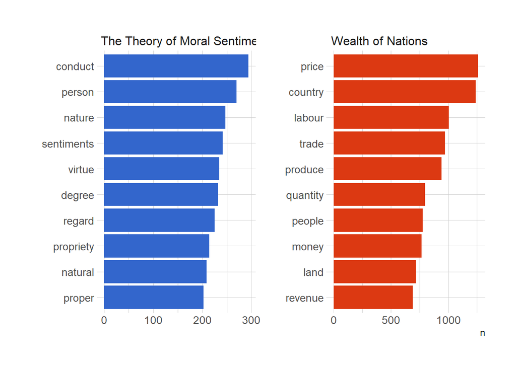

```r
smith_books_tidy %>%
  count(word, book) %>%
  group_by(book) %>%
  arrange(desc(n)) %>%
  top_n(10) %>%
  ggplot(aes(x = fct_reorder(word, n), y = n, fill = book)) +
    geom_col() +
    coord_flip() +
    hrbrthemes::theme_ipsum_tw() +
    facet_wrap(~ book, scales = "free") +
    ggthemes::scale_fill_gdocs(guide = FALSE) +
    labs(x = "")
```

From this simple text critical technique we can anecdotally surmise that

1. The texts differ in frequency of key words. Price contrasts with conduct; country with persons; quantity with virtue.
2. The top ten words for *Theory of Moral Sentiment* perhaps naturally as to the subject relate to persons, values, and categories of a moral, philosophical argument.
3. The top ten words relate to categories of markets, factors of production, accounting, and economic activity.

We can go further with an *n-gram* analysis.

```r
smith_bigrams <- smith_books %>%
  unnest_tokens(bigram, text, token = "ngrams", n = 2) %>%
  group_by(book)
# includes lots of otherwise stop words
# smith_bigrams %>%
#  count(bigram, sort = TRUE)
# excludes stop words
bigrams_separated <- smith_bigrams %>%
  separate(bigram, c("word1", "word2"), sep = " ")
bigrams_filtered <- bigrams_separated %>%
  filter(!word1 %in% stop_words$word) %>%
  filter(!word2 %in% stop_words$word)
# bigram counts
bigram_counts <- bigrams_filtered %>%
  group_by(book) %>%
  count(word1, word2, sort = TRUE)
head(bigram_counts)
```

```
## # A tibble: 6 x 4
## # Groups:   book [1]
##   book              word1   word2       n
##   <fct>             <chr>   <chr>   <int>
## 1 Wealth of Nations annual  produce   164
## 2 Wealth of Nations foreign trade     109
## 3 Wealth of Nations money   price      93
## 4 Wealth of Nations home    market     92
## 5 Wealth of Nations rude    produce    87
## 6 Wealth of Nations 0       0          77
```

Now we look for the most common bigrams (separated by " ", a blank space) using the `unite()` function.

```r
bigrams_united <- bigrams_filtered %>%
  unite(bigram, word1, word2, sep = " ")
head(bigrams_united)
```

```
## # A tibble: 6 x 3
## # Groups:   book [1]
##   book                           chapter bigram
##   <fct>                            <int> <chr>
## 1 The Theory of Moral Sentiments       0 moral sentiments
## 2 The Theory of Moral Sentiments       0 adam smith
## 3 The Theory of Moral Sentiments       0 smith professor
## 4 The Theory of Moral Sentiments       0 moral philosophy
## 5 The Theory of Moral Sentiments       0 glasgow london
## 6 The Theory of Moral Sentiments       0 london printed
```

Let’s busy ourselves with the frequency of terms and the inverse document frequency of terms (TF-IDF). The term frequency is simply the number of times a term, here a bigram, occurs relative to all terms, here bigrams. We weigh this relative frequency by an information importance measure called the inverse document frequency, which we define in natural logarithms as

$$IDF(term) = log
\left[\frac{n_{documents}}{n_{documents\,containing\,term}} \right]$$
This log ratio is related to, but not the same as, to the inverse of the odds in favor of seeing a document with the term versus any document.

We multiply the TF by the IDF to weigh the TF away from very common terms and toward terms that otherwise are infrequent.

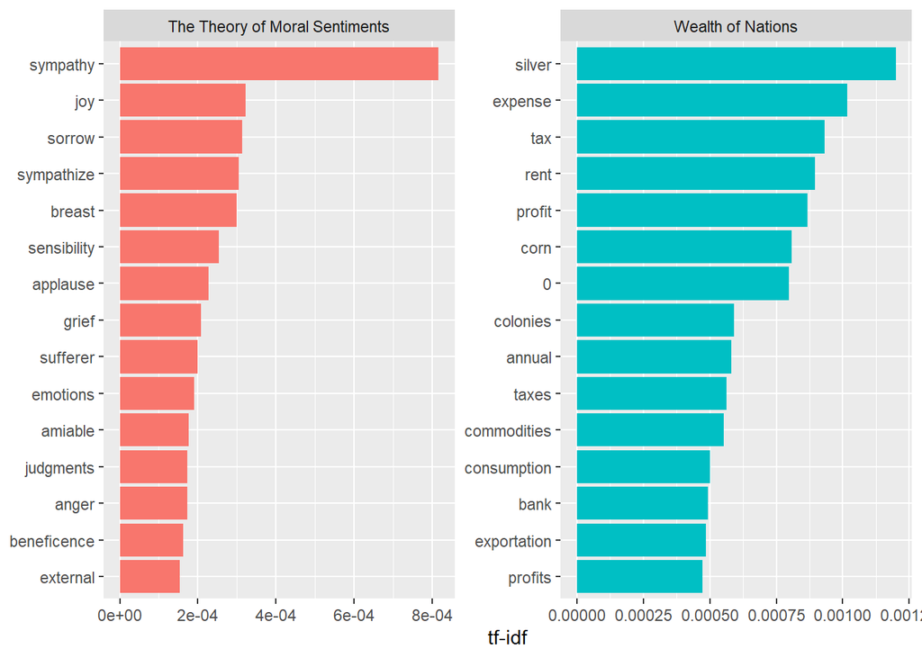

```r
library(janeaustenr)
book_words <- smith_books %>%
  unnest_tokens(word, text) %>%
  count(book, word, sort = TRUE)
book_tf_idf <- book_words %>%
  bind_tf_idf(word, book, n)
book_tf_idf %>%
  group_by(book) %>%
  slice_max(tf_idf, n = 15) %>%
  ungroup() %>%
  ggplot(aes(tf_idf, fct_reorder(word, tf_idf), fill = book)) +
  geom_col(show.legend = FALSE) +
  facet_wrap(~book, ncol = 2, scales = "free") +
  labs(x = "tf-idf", y = NULL)
```

```r
bigram_tf_idf <- bigrams_united %>%
  count(book, bigram) %>%
  bind_tf_idf(bigram, book, n) %>%
  arrange(desc(tf_idf))

head(bigram_tf_idf)
```

```
## # A tibble: 6 x 6
## # Groups:   book [2]
##   book                           bigram                  n      tf   idf  tf_idf
##   <fct>                          <chr>               <int>   <dbl> <dbl>   <dbl>
## 1 The Theory of Moral Sentiments impartial spectator    61 0.00692 0.693 0.00479
## 2 Wealth of Nations              annual produce        164 0.00586 0.693 0.00406
## 3 The Theory of Moral Sentiments fellow feeling         42 0.00476 0.693 0.00330
## 4 The Theory of Moral Sentiments proper object          38 0.00431 0.693 0.00299
## 5 Wealth of Nations              foreign trade         109 0.00390 0.693 0.00270
## 6 Wealth of Nations              money price            93 0.00332 0.693 0.00230
```

Of course, we want to see a picture of our handiwork (really Silge et al.!).

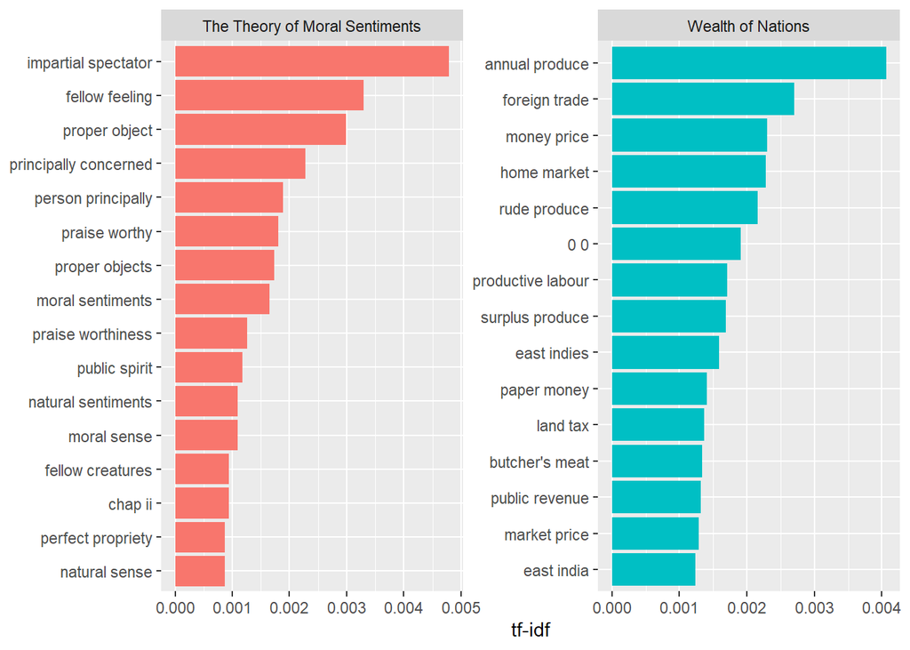

```r
library(forcats)
library(plotly)
plt <- bigram_tf_idf %>%
  group_by(book) %>%
  slice_max(tf_idf, n = 15) %>%
  ungroup() %>%
  ggplot(aes(tf_idf, fct_reorder(bigram, tf_idf), fill = book)) +
  geom_col( show.legend = FALSE ) +
  facet_wrap( ~ book, ncol = 2, scales = "free" ) +
  labs( x = "tf-idf", y = NULL )
plt
```

### Sentiment Analysis

A typical sentiment analysis will match words by frequency in corpora with a lexicon of conceptual and emotionally connotative words. The analysis will only be as good as the lexicon, as it presents a higher viewpoint of potential comparisons using corpora as data observed.

We can use the `tidytext` package to deploy several sentiment lexicons.

```r
glimpse(get_sentiments(lexicon = c("bing", "afinn", "loughran", "nrc")))
```

```
## Rows: 6,786
## Columns: 2
## $ word      <chr> "2-faces", "abnormal", "abolish", "abominable", "abominab...
## $ sentiment <chr> "negative", "negative", "negative", "negative", "negative...
```

Wherever a corpus has these words a match will be found in the lexicon. Sentiment scores can then be summed for each match.

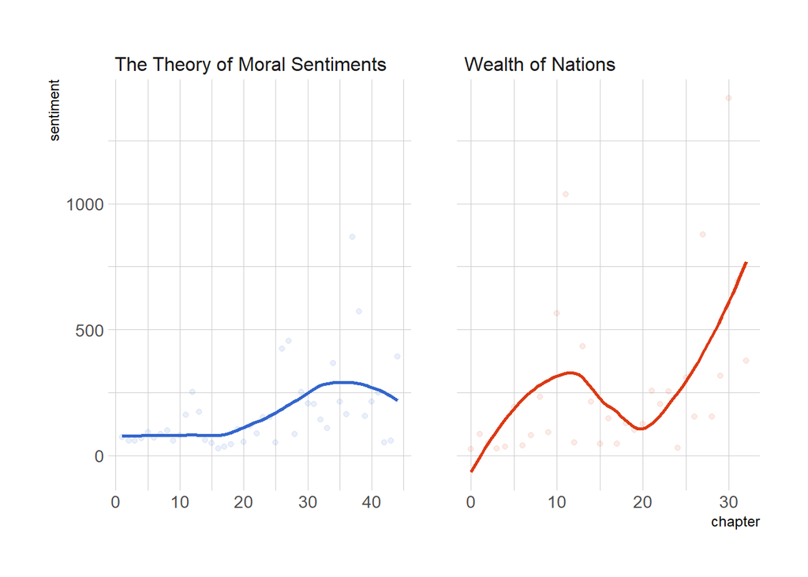

```r
d <- smith_books_tidy %>%
  inner_join(get_sentiments(lexicon = c("bing", "afinn", "loughran", "nrc"))) %>%
  mutate( score = ifelse( sentiment == "negative", 0, 1) ) %>%
  group_by(book, chapter) %>%
  summarise(sentiment = sum(score))
plt <- d %>%
  ggplot(aes(x = chapter, y = sentiment, color = book)) +
    geom_point(alpha = 1/10) +
    geom_smooth(se = FALSE) +
    facet_wrap(~ book, scales = "free_x") +
    hrbrthemes::theme_ipsum_tw() +
    ggthemes::scale_color_gdocs(guide = FALSE)
plt
```

### TF-IDF

Term Frequency (TF)-IDistribution Frequency techniwues adjusts the term frequency within document (in this case book) for the specificity of the term to that specific document. Thus, terms that are used in both books are weighted down, and terms that are used almost exclusively in one of the books are weighted up. The idea is to find the most distinctive terms for each book. My intuition tells me that this won’t be much too different from the original counts (very different vocabularies in the books). Just for the sake of it, let’s use bigrams:

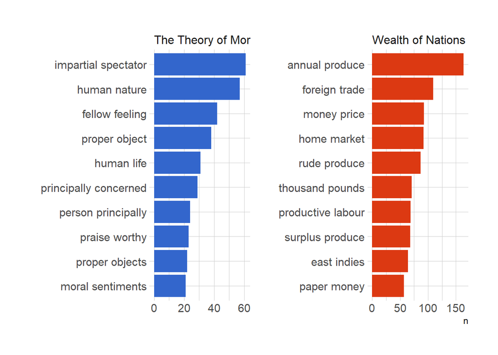

```r
smith_bigrams <- smith_books %>%
  unnest_tokens( bigram, text, token = "ngrams", n = 2 )
bigrams_separated <- smith_bigrams %>%
  separate( bigram, c( "word1", "word2" ), sep = " " )
bigrams_filtered <- bigrams_separated %>%
  filter( !word1 %in% stop_words$word ) %>%
  filter( !word2 %in% stop_words$word ) %>%
  filter( !str_detect(word1, "\\d" ),
          !str_detect(word2, "\\d" ) )
bigrams_united <- bigrams_filtered %>%
  unite( bigram, word1, word2, sep = " " )
bigrams_united %>%
  count( book, bigram ) %>%
  group_by( book ) %>%
  arrange( desc(n) ) %>%
  top_n( 10 ) %>%
  ggplot( aes( x = fct_reorder(bigram, n), y = n, fill = book ) ) +
    geom_col() +
    coord_flip() +
    facet_wrap( ~ book, scales = "free" ) +
    hrbrthemes::theme_ipsum() +
    ggthemes::scale_fill_gdocs( guide = FALSE ) +
    labs( x = "" )
```

With just the counts, the subject difference is even more striking, fjor example, human nature compared with foreign trade. We might even use the bigram for the “Theory” as the main subject of the book and not be completely wrong.

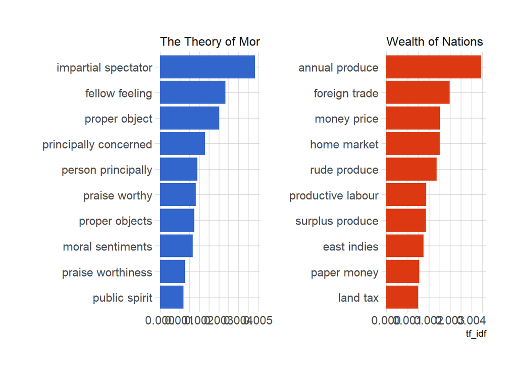

```r
bigrams_united %>%
  count( book, bigram ) %>%
  bind_tf_idf( bigram, book, n ) %>%
  group_by( book ) %>%
  arrange( desc(tf_idf) ) %>%
  top_n( 10 ) %>%
  ggplot( aes(x = fct_reorder(bigram, tf_idf), y = tf_idf, fill = book ) ) +
    geom_col() +
    coord_flip() +
    facet_wrap( ~ book, scales = "free" ) +
    hrbrthemes::theme_ipsum() +
    ggthemes::scale_fill_gdocs( guide = FALSE ) +
    labs(x = "")
```

The TF-IDF adjustment did not change much.

### A network of words

We can depict word pairs as nodes with correlated edges.

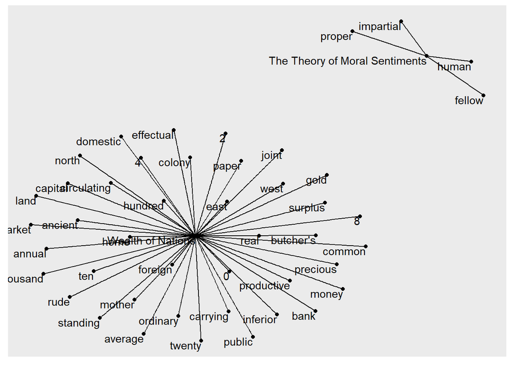

```r
library(igraph)
# filter for only relatively common combinations
bigram_graph <- bigram_counts %>%
  filter(n > 30) %>%
  graph_from_data_frame()

#bigram_graph
library(ggraph)
set.seed(42)

ggraph(bigram_graph, layout = "fr") +
  geom_edge_link() +
  geom_node_point() +
  geom_node_text(aes(label = name), vjust = 1, hjust = 1)
```

Bigrams are interesting artifacts because they represent specific constrained word pairings. In linguistics there are also other pairings including mono- and bigram pairings we might investigate using a correlation design. We can analyze pairs of words, and also bigrams, which more likely appear within a defined distance, such as a chapter or section, rather than just by themselves. This is the beginning of building a semantic structure.

Then

$$\phi = \frac{n_{11}n_{00}-n_{10}n_{01}}{\sqrt{(n_{00}+n_{10})(n_{01}+n_{11})(n_{00}+n_{01})(n_{10}+n_{11})}}$$
The following bordered sums frequency table summarizes the calculation.

$$\begin{bmatrix}
&|& not\,X & Y & | & \\
-----& | & ----- & ---- & | & ----- \\
not\,X & | & n_{00} & n_{01} & | & n_{00} + n_{01} \\
Y & | & n_{10} & n_{11} & | & n_{10} + n_{11} \\
-----& | & ----- & ----- & & -----\\
& | & n_{00}+n_{10} & n_{01}+n_{11} & | & n
\end{bmatrix}$$
These are all in row-column configuration, where, for example $n_{01}$ is the number of times in the corpus $not\,X$ and $Y$ occur. Also $n$ is the number of occurrences of either $X$ or $Y$. It would be correct to interpret the numerator of $\phi$ as a binary covariance of $X$ with $Y$ and the numerator as the product of the standard deviations of $X$ and $Y$ occurring.

```r
# unfertige Erzeugnisse
#
# another function whose flow we might want to repeat
# first a bespoke function to build a group-wise pairing correlation
pairwise_book <- function(df) {
  df %>%
  group_by(word) %>%
  filter(n() >= 100) %>%
  pairwise_cor(word, chapter, sort = TRUE)
}
# back to the tidy version of the books
smith_correlations <- smith_books_tidy %>%
  filter(!str_detect(word, "\\d")) %>%
  group_by(book) %>%
  do(pairwise_book(.)) %>%
  group_by(book) %>%
  arrange(desc(correlation)) %>%
  top_n(20, correlation) %>% ungroup
```

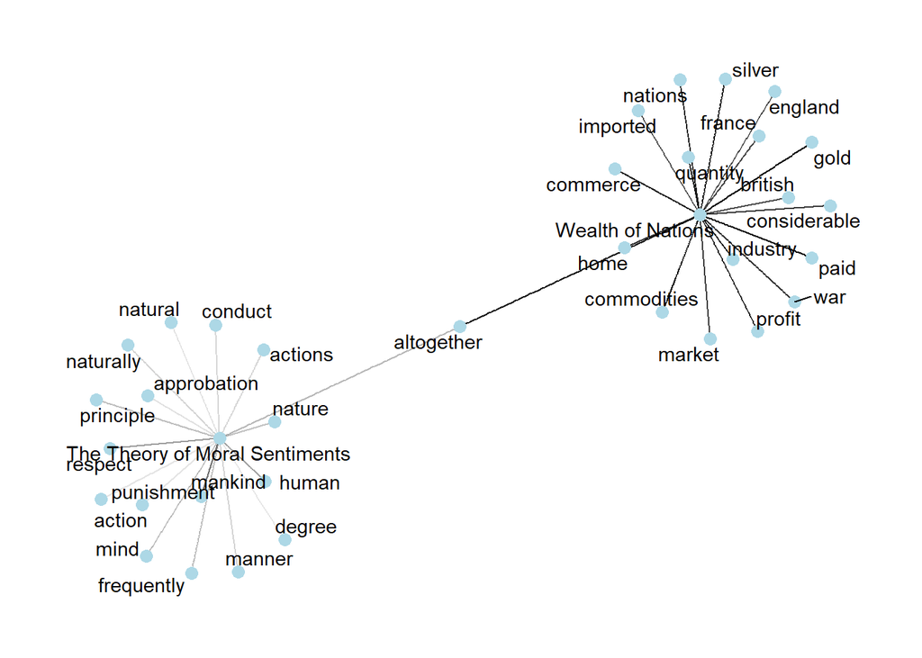

```r
smith_correlations %>%
  ggraph( layout = "fr" ) +
  geom_edge_link(aes(edge_alpha = correlation), show.legend = FALSE) +
  geom_node_point(color = "lightblue", size = 3) +
  geom_node_text(aes(label = name), repel = TRUE) +
  theme_graph()
```

```r
corr_graph <- function(df) {
  ggraph(df, layout = "fr") +
  geom_edge_link(aes(edge_alpha = correlation), show.legend = FALSE) +
  geom_node_point(color = "lightblue", size = 3) +
  geom_node_text(aes(label = name), repel = TRUE) +
  theme_graph()
}
smith_data <- smith_correlations %>%
  filter(correlation > 0.1) %>%
  group_by(book)
smith_data %>%
  ggraph( layout = "fr") +
  geom_edge_link(aes(edge_alpha = correlation), show.legend = FALSE) +
  geom_node_point(color = "lightblue", size = 3) +
  geom_node_text(aes(label = name), repel = TRUE) +
  theme_graph()
smith_data[[2]] %>%
  map(graph_from_data_frame) %>%
  map(corr_graph) %>%
  reduce(cowplot::plot_grid, labels = c("Wealth of Nations", "Theory of Moral Sentiments"))
  # %>%
#  nest()
```

[output not shown]

We have two very dintinct clusters linked by *altogether*. In other parameterizations and filters the word is *human*. Words in *Moral* are abstract, conceptual, a turn of philosophical terminology about the human condition and decisions made by humans in this condition. Notions of value, judgment, nature, and even probability enter the network.

The words in the network of ideas in *Wealth* denote specific times, places, amounts, nations, products, price as value, markets as the nexus of human exchange, bellicose events, and political forces. Words in *Wealth* are practical, measurable, observable immediately, and related through commerce and polity.

## Some provisional hypotheses

In a sense, without knowing anything except the assumed common authorship of the two works, one hypothesis is that *Wealth* is the practical science of an *applied Morality*.

Another hypothesis, given that the publication of *Moral* comes before that of *Wealth* is whether or not the contentions in *Moral* continue into *Wealth*.